# Analysis of Chicago Homicides:1957 - 2016

### Analysis Overview

This is a brief analysis of the monthly homicide data as reported by the Chicago Police Department and published by the Chicago Tribune. Data used in this analysis is from the March 2016 Chicago Tribune article, “Data: Chicago homicide data since 1957”, (http://www.chicagotribune.com/news/local/breaking/ct-chicago-homicides-data-since-1957-20160302-htmlstory.html). Homicides are noted as criminal or unlawful killings. Supplemental data pertaining to the residing administrations are added for further context. This analysis compares homicides over the past 59 years.

### Tenure of Each Administration

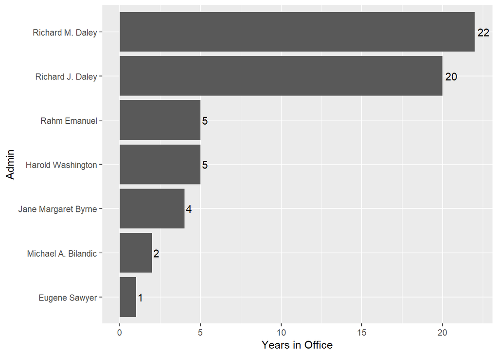

### Homicide Count by Administration

The homicide counts for Richard J. Daley and Richard M. Daley are expected to be exponentially more than the other administrations given their tenure in office. Below summaries the total number of homicides under each administration. The figures are assumed to be influenced to some degree by economic factors, political climates and/or weather which are not quantified in the data to any significant detail.

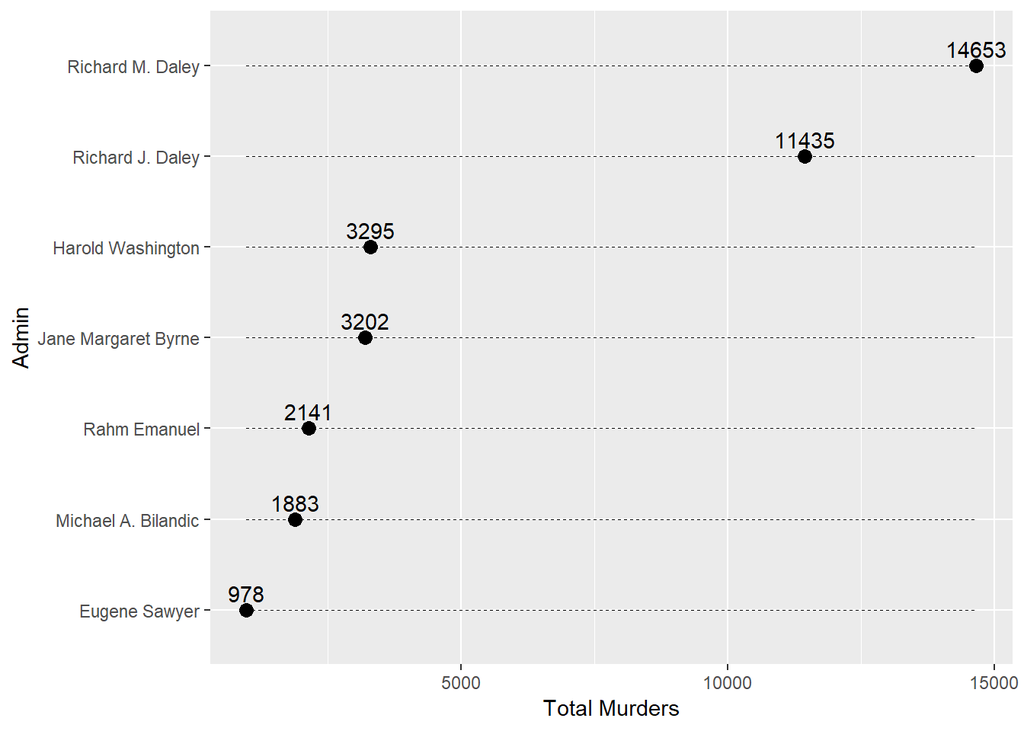

### Homicide Patterns

Recent homicide patterns suggest a recent downward trend with murders peaking in 1974 and 1992 at 970 and 943 respectively.

| year | total_murders | proportion |
| --- | --- | --- |
| 1974 | 970 | 0.03 |
| 1992 | 943 | 0.03 |

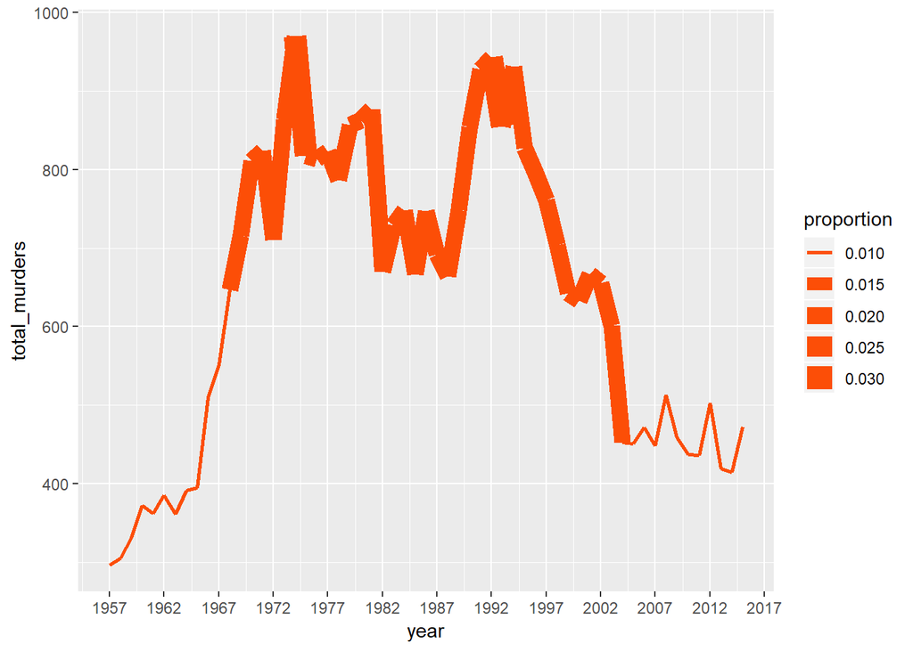

### Seasonal Patterns

Homicides over the past 59 years generally peak in the summer months. Administrations of 4 years or more exhibit similar patterns which are not captured by administrations of lesser duration.

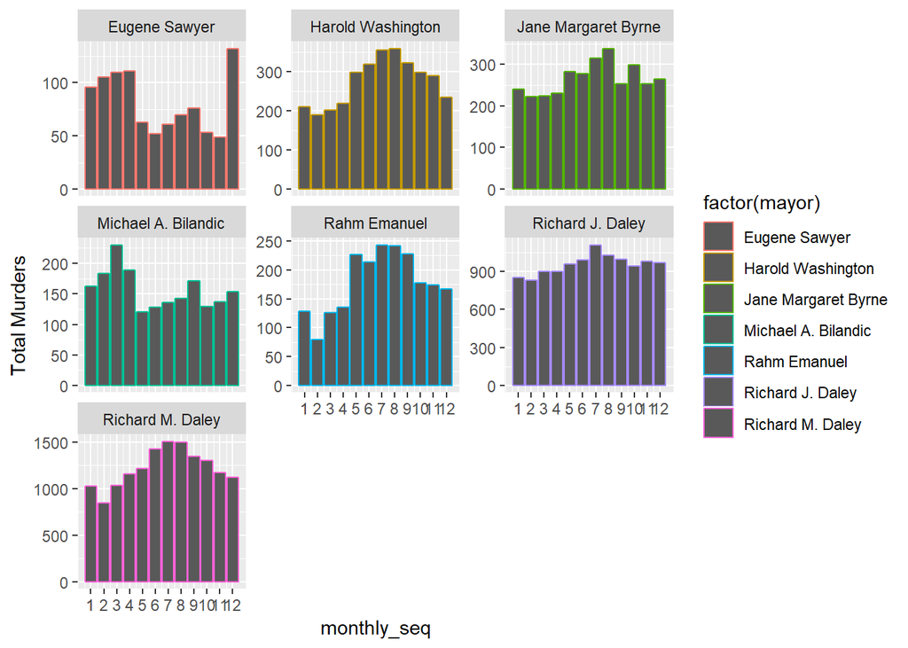

### Percent Change in Homicide: 2010-2013 vs 2013-2016

The mean percentage change in homicide between 2010 - 2013 and 2013 - 2016 is -0.01. On average, the mean percentage change during this period declined -0.22 and -0.18 in January and October respectively, partially offset by an increase of 0.35 in September.

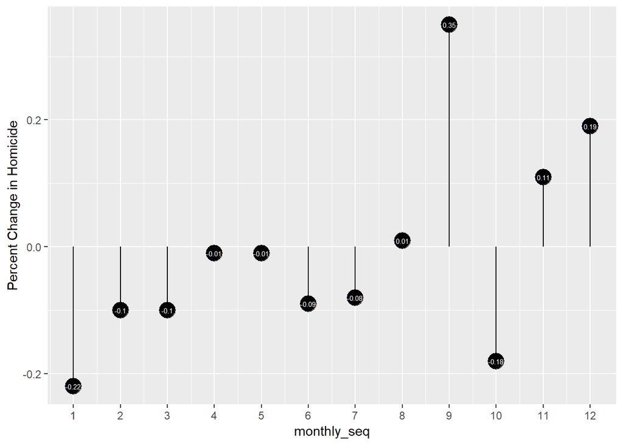